# Homework 3: Is Donald Trump going to win the republican nomination?

**This homework is due Tuesday March 8, 2016 at 8PM EST. When complete, submit your code in an R Markdown file and the knitted HTML via GitHub.**

# Motivation

In 2012 Nate Silver, and other data scientists, [predicted the outcome of each state correctly](http://mashable.com/2012/11/07/nate-silver-wins/#2WkAUaXCVaqw). They did this by aggregating data from many polls to create more precise estimates than what one single poll can provide.

In this homework, we will try to predict the results of the democratic and republican primaries by studying the performance of polls in elections that already occurred and then aggregating results.

# Problem 1

The first step in our analysis will be to wrangle the data in a way that will simplify the analysis. Ultimately, we want a table of results with each poll represented by a row and including results for each candidate as well as information about the poll such as name and date.

## Problem 1A

Install and load the `pollstR` package. This package provides functions to access data in the Huffington Post’s database. Read the help file for the `pollstr_polls()` function and write a function that reads **all** the polls related to the republican primaries. Name the object `race2016`. Hint: Visit [this webpage](http://elections.huffingtonpost.com/pollster/api) to select the right `topic` and make sure to change the `max_pages` argument.

## Problem 1B

Examine and familiarize yourself with the `race2016` object. Note that the `questions` component has a table with election results. Look at the `topic` component of the `questions` component. Create a new table with only the results from the `2016-president-gop-primary` and only state (or territory) polls, no national polls. Hint: create a new object called `results` with the table of results and use `dplyr`. How many rows are we left with?

```r
library(dplyr)
results<-tbl_df(race2016$questions)
results<-filter(results,topic=="2016-president-gop-primary"&state!="US")
results%>%summarize(n())
```

```
## Source: local data frame [1 x 1]
##
##     n()
##   (int)
## 1  4855
```

```r
results<-unique(results)
results%>%summarize(n())
```

```
## Source: local data frame [1 x 1]
##
##     n()
##   (int)
## 1  4639
```

## Problem 1C

In Problem 1B, we created a table called `results` with over 4000 rows. Does this mean that we have data for 4000 polls? How many polls did we actually have? Hint: look at the `id` column and use the `group_by` command.

```r
results%>%group_by(id)#%>%nrow
```

```
## Source: local data frame [4,639 x 14]
## Groups: id [392]
##
##                                        question
##                                           (chr)
## 1  2016 Florida Republican Presidential Primary
## 2  2016 Florida Republican Presidential Primary
## 3  2016 Florida Republican Presidential Primary
## 4  2016 Florida Republican Presidential Primary
## 5  2016 Florida Republican Presidential Primary
## 6  2016 Florida Republican Presidential Primary
## 7  2016 Florida Republican Presidential Primary
## 8  2016 Florida Republican Presidential Primary
## 9  2016 Florida Republican Presidential Primary
## 10 2016 Florida Republican Presidential Primary
## ..                                          ...
## Variables not shown: chart (chr), topic (chr), state (chr), subpopulation
##   (chr), observations (int), margin_of_error (dbl), choice (chr), value
##   (int), first_name (chr), last_name (chr), party (chr), incumbent (lgl),
##   id (int)
```

## Problem 1D

Look at the first row of your `results` table. What date was this poll conducted? Hint: Use the `polls` component of the `race2016` object to find the date.

```r
polls<-tbl_df(race2016$polls)
polls%>%select(start_date,end_date)
```

```
## Source: local data frame [911 x 2]
##
##    start_date   end_date
##        (date)     (date)
## 1  2016-03-08 2016-03-09
## 2  2016-03-07 2016-03-09
## 3  2016-03-05 2016-03-09
## 4  2016-03-03 2016-03-07
## 5  2016-03-08 2016-03-08
## 6  2016-03-05 2016-03-08
## 7  2016-03-05 2016-03-08
## 8  2016-03-02 2016-03-07
## 9  2016-03-04 2016-03-07
## 10 2016-03-02 2016-03-07
## ..        ...        ...
```

## Problem 1E

Now examine the candidates in the “choices” column included in `results` table. Hint: use the `table()` function. Note that there are several choices that not going to be informative. For example, we have candidates that have dropped out. We also have entries such as `No one`, `No One` and `No Preference`. Filter the `results` table to include only Rubio and Trump.

```r
results<-filter(results,choice%in%c("Trump","Rubio"))
table(results$choice)
```

```
##
## Rubio Trump
##   391   342
```

## Problem 1F

In our `results` table, we have one row for each candidate in each poll. Transform the `results` table to have one row for each poll and columns for each Rubio and Trump. Next, create a column called `diff` with the difference between Trump and Rubio. Hint: Remove the `first_name` and `last_name` columns then use the `tidyr` function `spread()`.

```r
library(tidyr)
results<-select(results,-first_name,-last_name)
results<-results%>%spread(key=choice,value=value)
results<-results%>%mutate(Trump=as.numeric(Trump)/100,Rubio=as.numeric(Rubio)/100)
results<-results%>%mutate(diff=Trump-Rubio)
```

## Problem 1G

For each poll in the `results` table, we want to know the start date and the end date of the poll along with the pollster name and the type of poll it was. Hint: This information is in the `polls` component of `race2016`. You can select the relevant columns then use the `id` column to join the tables. One of the `join` functions in `tidyr` will do the trick.

```r
polls<-select(polls,id:method)
results<-left_join(results,polls,by="id")
```

## Problem 1H

Study the type of values in the `pollster` column. Notice that you have many different values but that certain names commonly appear in these values. For example, consider the name “NBC” in the `pollster` column. NBC here is the Survey House. Use a join function again to add the survey house to the `results` table. Rename the column `house`. Hint: `race2016$survey_house` has the information you need.

```r
houses<-race2016$survey_houses
houses<-houses%>%select(name,id)
names(houses)<-c("house","id")
results<-left_join(results,houses,by="id")
```

# Problem 2

We now have a table with all the information we need. We will now use the results from Iowa, New Hampshire, Nevada and South Carolina to determine how to create a prediction for upcoming primaries.

## Problem 2A

Use an internet search to determine the results for the Iowa, New Hampshire, Nevada and South Carolina primaries for the top two candidates. Create a table called `actual` with this information. Also, create a column with the actual election difference. Use a join function to add this information to our `results` table.

```r
actual<-data.frame(state=c("IA","NH","NV","SC"),aTrump=c(0.24,0.35,0.46,0.33),aRubio=c(0.23,0.11,0.24,0.22))
actual<-mutate(actual,adiff=aTrump-aRubio)
results<-left_join(results,actual,by="state")
```

## Problem 2B

Create boxplots of the poll results for Trump in Iowa stratified by the pollster survey house for polls having more than 4 total results. Add a horizontal line with the actual results. Hint: Use the `group_by`, `mutate`, `filter` and `ungroup` functions in `dplyr` for the filtering step.

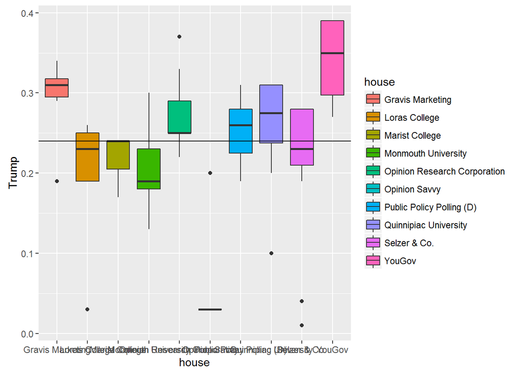

```r
library(ggplot2)
results%>%
  filter(state=="IA")%>%
  group_by(house)%>%
  mutate(num_polls=n())%>%
  filter(num_polls>4)%>%
  ungroup%>%
  ggplot(aes(house,Trump,fill=house),)+geom_boxplot()+geom_hline(aes(yintercept=actual$aTrump[1]))
```

## Problem 2C

Using the poll results for Trump in Iowa, compute the standard deviation for the results from each pollster house for polls having more than 4 total results. Then, study the typical standard deviation sizes used in these polls. Create a new table with two columns: the observed standard deviation and the standard deviations that theory predicts. For the prediction you have several observations. Pick the smallest one. Which is larger, the observed or the theoretical?

```r
results%>%
  filter(state=="IA",is.na(Trump)==FALSE)%>%
  group_by(house)%>%
  mutate(num_polls=n())%>%
  filter(num_polls>4)%>%
  summarise(min_n=min(observations),sd_sam=sd(Trump),sd_the=sqrt(mean(Trump)*(1-mean(Trump)))/ sqrt(min_n))
```

```
## Source: local data frame [9 x 4]
##
##                          house min_n     sd_sam     sd_the
##                          (chr) (int)      (dbl)      (dbl)
## 1             Gravis Marketing   356 0.05316641 0.02413032
## 2                Loras College   499 0.09444575 0.01763218
## 3          Monmouth University   400 0.06348228 0.02022152
## 4 Opinion Research Corporation   266 0.05411628 0.02735543
## 5                Opinion Savvy   552 0.07602631 0.01041738
## 6    Public Policy Polling (D)   488 0.04457204 0.01968791
## 7        Quinnipiac University   574 0.07269064 0.01816307
## 8                 Selzer & Co.   400 0.08687598 0.02031042
## 9                       YouGov   492 0.05330170 0.02137539
```

The observed standard deviation is larger.

## Problem 2D

Now using the data from Problem 2C, plot the individual values against the time the poll was taken (use the `end_date`). Repeat this for each of the four states. Use color to denote pollster house. Using this plot, explain why the theory does not match the observed results?

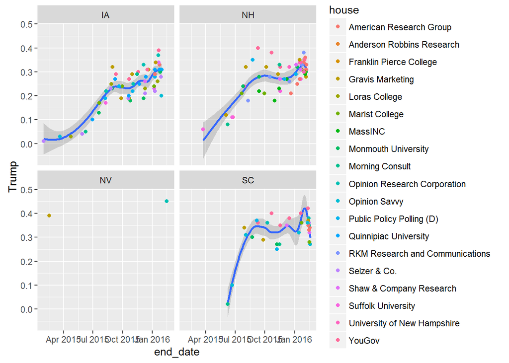

```r
results%>%
  filter(state%in%c("IA","NH","NV","SC"),is.na(Trump)==FALSE)%>%
  group_by(house)%>%
  mutate(num_polls=n())%>%
  filter(num_polls>4)%>%
  ggplot(aes(end_date,Trump))+ geom_smooth(span=0.5)+geom_point(aes(color=house)) +facet_wrap(~state)
```

## Problem 2E

Consider the Trump - Rubio difference. For each poll in IA, NH, SC and NV, compute the error between the prediction and actual election results. Use exploratory data analysis to get an idea of how time and pollster impacts accuracy.

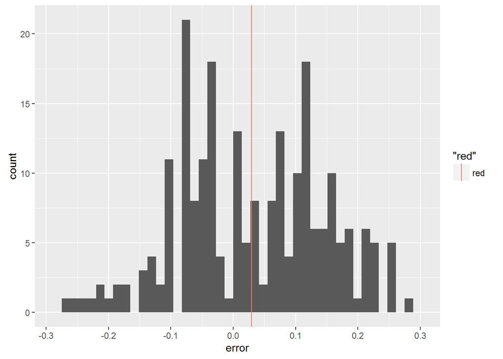

```r
results_error<-results%>%
   filter(state%in%c("IA","NH","NV","SC"),is.na(diff)==FALSE)%>%
   mutate(error=diff-adiff)
#error<-results_error$error
#end_date<-results_error$end_date
#hist(error)
#plot(end_date,error)
#abline(h=mean(error))
results_error%>%
  ggplot(aes(error))+geom_histogram(bins=40)+geom_vline(aes(xintercept = mean(error), color = "red"))
```

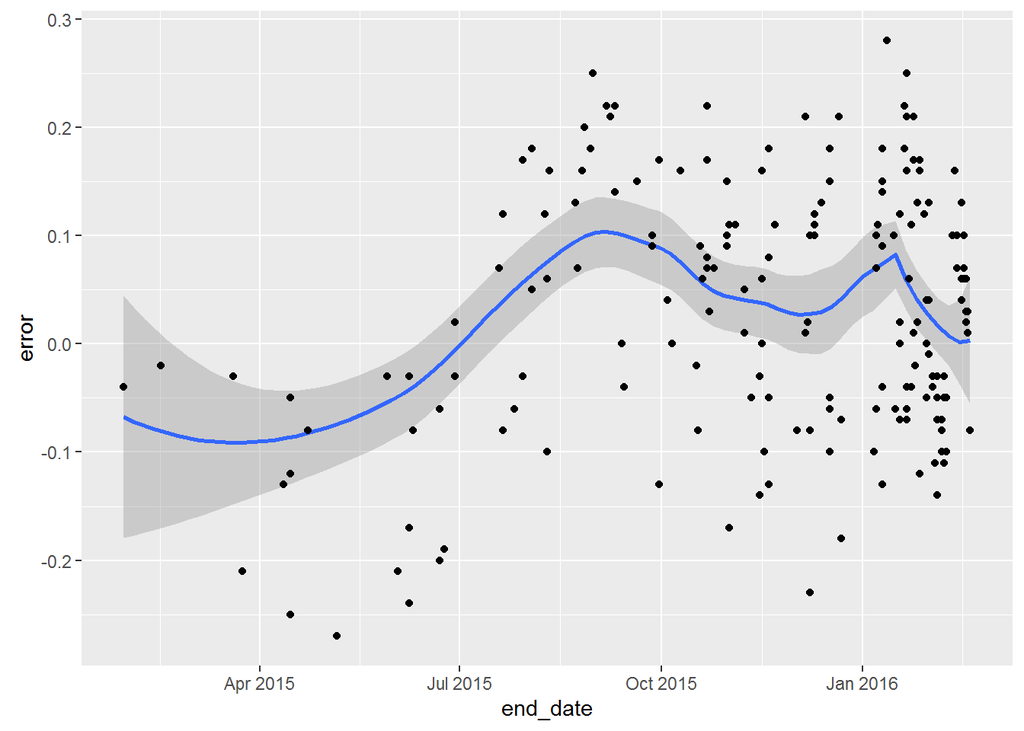

```r
results_error%>%
  ggplot(aes(end_date,error))+ geom_smooth(span=0.5)+geom_point()
```

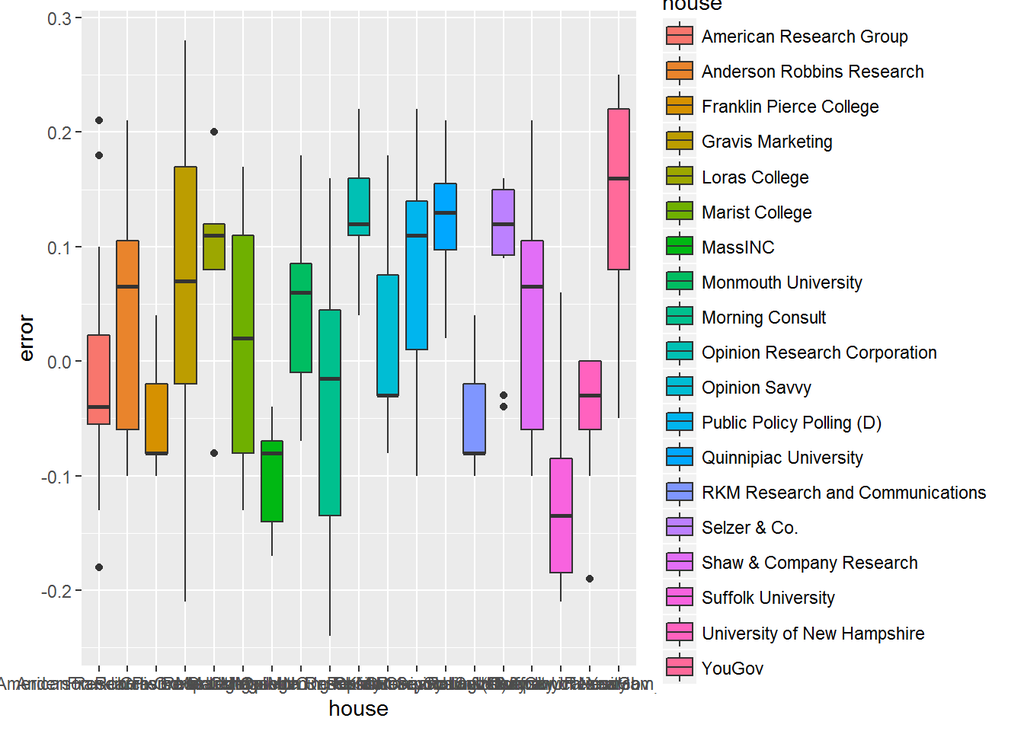

```r
results_error%>%
  group_by(house)%>%
  filter(n()>4)%>%
  ggplot(aes(house,error,fill=house),)+geom_boxplot()
```

## Problem 2F

For polls from IA, NH, and SC, aggregate all polls from within 1 week of the election (use the `start_date` to determine cutoff) to provide a 95% confidence interval for the difference between Trump and Rubio. Compare the following two approaches: (1) the method that assumes that all variance comes from sampling error and (2) the approach that estimates variance empirically.

```r
#IA:Jan 25-Feb 1 NH:Feb 2-Feb 9 SC:Feb 13-Feb 20
results_date<-results%>%
  filter(!is.na(diff))%>%
  filter((state=="IA"&start_date>=as.Date("2016-01-25"))|(state=="NH"&start_date>=as.Date("2016-02-02"))|(state=="SC"&start_date>=as.Date("2016-02-13")))

#provide ci
ci_p<-results_date%>%
  summarize(theta_hat=mean(diff),
            sigma_hat=sd(diff),
            tot_poll=n())
ci_p
```

```
## Source: local data frame [1 x 3]
##
##   theta_hat  sigma_hat tot_poll
##       (dbl)      (dbl)    (int)
## 1 0.1504545 0.04286021       44
```

```r
ci_p$theta_hat+c(-1,1)*(ci_p$sigma_hat/sqrt(ci_p$tot_poll))*qnorm(0.975)
```

```
## [1] 0.1377904 0.1631187
```

# Problem 3

Before seeing any polls my *prior belief* is that Rubio will beat Trump in Florida. If I were to quantify this belief I would say that the distribution of the `Trump` - `Rubio` was normal with mean $\mu=-20$ percent and standard deviation $\tau=10$. Let’s call the difference $\theta$. Then

$$\theta \sim N( \mu, \tau)$$

## Problem 3A

Under my prior belief, what is the chance that Trump would beat Rubio in Florida.

```r
mu_prior=-20/100
tau_prior=10
1-pnorm(0,mu_prior,tau_prior)
```

```
## [1] 0.4920217
```

## Problem 3B

Consider the latest 25 Florida polls. Assume the poll results for the difference are normal distributed with mean $\theta$ and standard deviation $\sigma$. Provide an estimate for $\theta$ and an estimate of the standard deviation $\sigma$.

```r
results_fl<-results%>%
  filter(state=="FL")%>%
  arrange(desc(end_date))
results_fl%>%
  filter(end_date>="2015-09-13")%>%
  summarize(theta_hat=mean(diff),sigma_hat=sd(diff))
```

```
## Source: local data frame [1 x 2]
##
##   theta_hat  sigma_hat
##       (dbl)      (dbl)
## 1 0.1560606 0.06782051
```

$$\hat{\theta} \sim N( \theta, \sigma/ \sqrt{25})$$

Now use the Central Limit Theorem to construct a confidence interval.

```r
ci_parameter<-results_fl%>%
  filter(end_date>="2015-09-13")%>%
  summarize(theta_hat=mean(diff),sigma_hat=sd(diff),tot_poll=n())
ci_parameter$theta_hat+c(-1,1)*(ci_parameter$sigma_hat/sqrt(ci_parameter$tot_poll))*qnorm(0.975)
```

```
## [1] 0.1329212 0.1792000
```

## Problem 3C

Combine these two results to provide the mean and standard deviation of a posterior distribution for $\theta$.

```r
N <- ci_parameter$tot_poll
B <- (1/tau_prior^2) / (N / ci_parameter$sigma_hat^2 + 1/tau_prior^2)
sd_post <- sqrt( (1 / tau_prior^2 + N / ci_parameter$sigma_hat^2)^(-1) )
mu_post <- mu_prior * B + ci_parameter$theta_hat * (1-B)
mu_post
```

```
## [1] 0.1560601
```

```r
sd_post
```

```
## [1] 0.01180603
```

## Problem 3D

Use the result form Problem 3C to provide your estimate of Trump beating Rubio in Florida.

```r
1-pnorm(0,mu_post,sd_post)
```

```
## [1] 1
```

# Problem 4

Use the poll data as well as the results from Super Tuesday (March 1st) and other election results that happen before the deadline to make predictions for each remaining primary. Then use these results to estimate the probability of Trump winning the republican nomination. Justify your answer with figures, statistical arguments, and Monte Carlo simulations.

It will help to learn about how delegates are assigned. Here is [the manual].(http://www.scribd.com/doc/294928557/2016-Presidential-Nominating-Process-Book-version-2-0-Dec-2015-pdf)

Before deadline, there are many states that already have results.Basically, Trump won 458 delegates and Cruz won 359 delegates. So our prediction will focus on these two candidates.

```r
#load poll results
library(dplyr)
results<-tbl_df(race2016$questions)
results<-filter(results,topic=="2016-president-gop-primary"&state!="US")
results<-unique(results)


#load poll date
polls<-tbl_df(race2016$polls)

#focus on Trump and Cruz
results<-filter(results,choice%in%c("Trump","Cruz"))
table(results$choice)
```

```
##
##  Cruz Trump
##   387   342
```

```r
#clean data
library(tidyr)
results<-select(results,-first_name,-last_name,-question,-topic,-chart,-incumbent,-party)
results<-results%>%spread(key=choice,value=value)
results<-results%>%filter(!is.na(Trump)&!is.na(Cruz))
results<-results%>%mutate(Trump=as.numeric(Trump)/100,Cruz=as.numeric(Cruz)/100)
results<-results%>%mutate(diff=Trump-Cruz)

#add polls
polls<-select(polls,id:method)
results<-left_join(results,polls,by="id")
```

First, we should check the poll results.

```r
length(unique(results$state))
```

```
## [1] 30
```

We only have polls results from 30 states so we will make predictions on the remaining states.

```r
unique<-unique(results$state)
previous<-c("IA","NH","SC","NV","AL","AK","AR","GA","MA","MO","OK","TN","TX","VT","VA","KS","KY","LA","ME","HI","ID","MI","MS")
results<-results%>%filter(!(state%in%previous))
length(unique(results$state))
```

```
## [1] 12
```

```r
pstates<-unique(results$state)
```

So we only have 12 states to make predictions.We assign delegates to these states

```r
pdelegates<-c(58,172,99,69,72,51,95,66,71,40,42,34)
library(dplyr)
delegate<-data.frame(state=pstates,delegate=pdelegates)
```

We assume that in all states the distribution of $\theta$ is normal with mean $\mu = 0$ and standard deviation $\tau = 10$

```r
mu_prior=0
tau_prior=10
1-pnorm(0,mu_prior,tau_prior)
```

```
## [1] 0.5
```

Then we explore the data to estimate $\theta$ and $\tau$

```r
results%>%
  group_by(state)%>%
  summarize(num_poll=n())
```

```
## Source: local data frame [12 x 2]
##
##    state num_poll
##    (chr)    (int)
## 1     AZ        2
## 2     CA        3
## 3     FL       32
## 4     IL        2
## 5     NC       15
## 6     NJ        5
## 7     NY        1
## 8     OH        9
## 9     PA        6
## 10    UT        4
## 11    WI        2
## 12    WV        1
```

For FL, NC, OH and PA, there are more poll results.For other states, there are very few poll results.We mainly focus on these four states.

1.FL

```r
tabEst<-results%>%
  filter(state=="FL")%>%
  summarize(theta_hat=mean(diff),sigma_hat=sd(diff),tot_poll=n())
tabEst
```

```
## Source: local data frame [1 x 3]
##
##   theta_hat  sigma_hat tot_poll
##       (dbl)      (dbl)    (int)
## 1   0.20125 0.07698974       32
```

Here, we ignore the time effect and house effect. We assume that these effects will not affect the results largely.

However, we could also use election results and poll results in those states that already have results to evalute the time effect and house effect. Here we choose to ignore them.

```r
N <- tabEst$tot_poll
B <- (1/tau_prior^2) / (N / tabEst$sigma_hat^2 + 1/tau_prior^2)
sd_post <- sqrt( (1 / tau_prior^2 + N / tabEst$sigma_hat^2)^(-1) )
mu_post <- mu_prior * B + tabEst$theta_hat * (1-B)
```

So in FL, the probability of Trump beating Cruz is

```r
1 - pnorm(0, mu_post, sd_post)
```

```
## [1] 1
```

We can confirm it by Monte Carlo simulation.

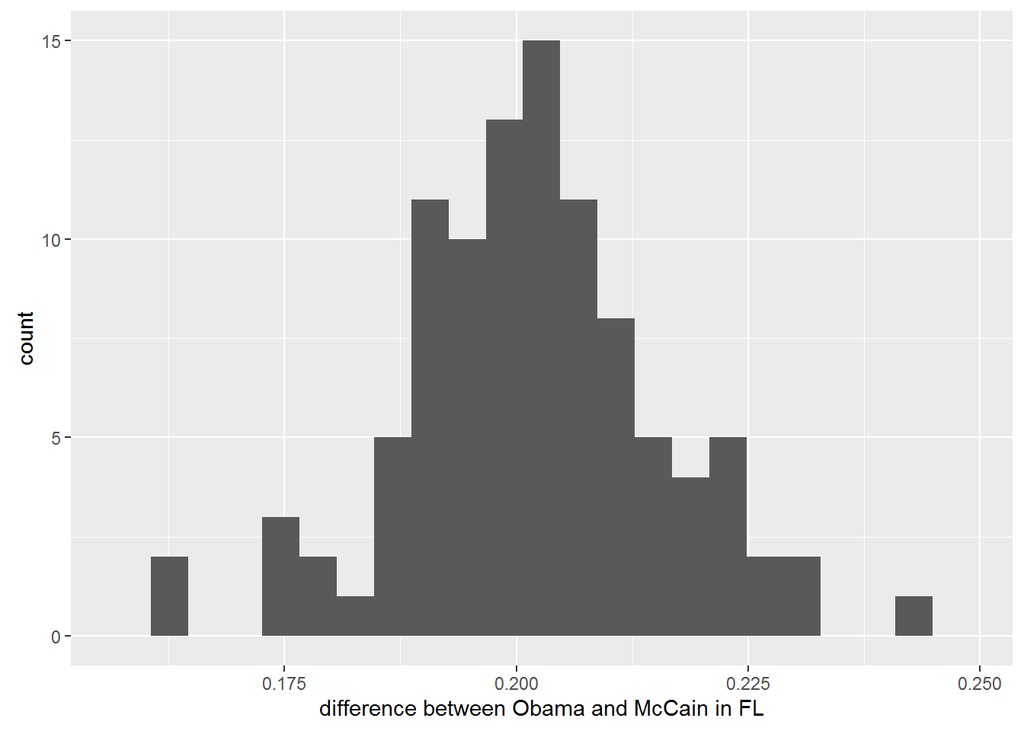

```r
N = 100
set.seed(1234)
qplot(rnorm(N,mu_post,sd_post), geom = "histogram", bins = 20,
      xlab = "difference between Obama and McCain in FL")
```

```r
mean(rnorm(N,mu_post,sd_post)>0)
```

```
## [1] 1
```

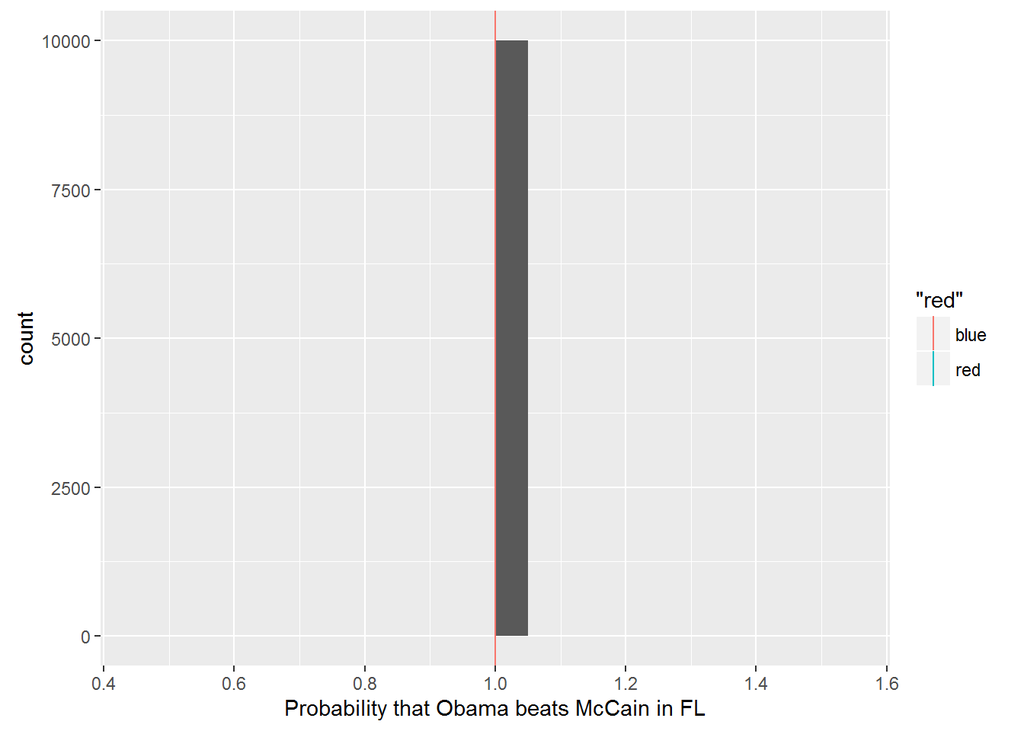

```r
N = 100
B = 1e4
result <- replicate(B, {
    X <- mean(rnorm(N,mu_post,sd_post) > 0)
})
qplot(result, geom = "histogram", bins = 20,
      xlab = "Probability that Obama beats McCain in FL") +
    geom_vline(aes(xintercept = mean(result), color = "red")) +
    geom_vline(aes(xintercept = 1 - pnorm(0, mu_post, sd_post), color = "blue"))
```

So Trump is more likely to win in FL.

2.NC

```r
tabEst<-results%>%
  filter(state=="NC")%>%
  summarize(theta_hat=mean(diff),sigma_hat=sd(diff),tot_poll=n())
tabEst
```

```
## Source: local data frame [1 x 3]
##
##   theta_hat  sigma_hat tot_poll
##       (dbl)      (dbl)    (int)
## 1 0.1433333 0.06365831       15
```

```r
N <- tabEst$tot_poll
B <- (1/tau_prior^2) / (N / tabEst$sigma_hat^2 + 1/tau_prior^2)
sd_post <- sqrt( (1 / tau_prior^2 + N / tabEst$sigma_hat^2)^(-1) )
mu_post <- mu_prior * B + tabEst$theta_hat * (1-B)
```

So in NC, the probability of Trump beating Cruz is

```r
1 - pnorm(0, mu_post, sd_post)
```

```
## [1] 1
```

We can confirm it by Monte Carlo simulation.

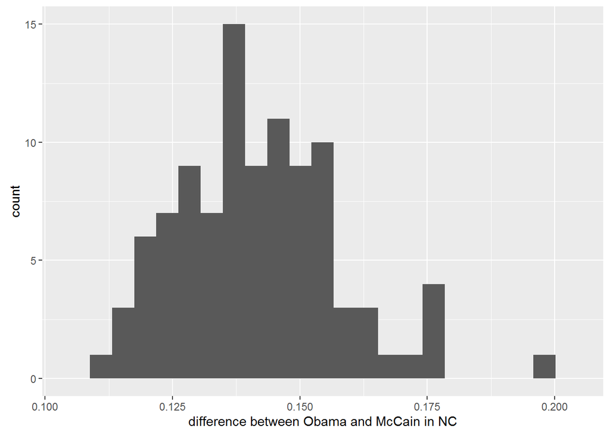

```r
N = 100
set.seed(123)
qplot(rnorm(N,mu_post,sd_post), geom = "histogram", bins = 20,
      xlab = "difference between Obama and McCain in NC")
```

```r
mean(rnorm(N,mu_post,sd_post)>0)
```

```
## [1] 1
```

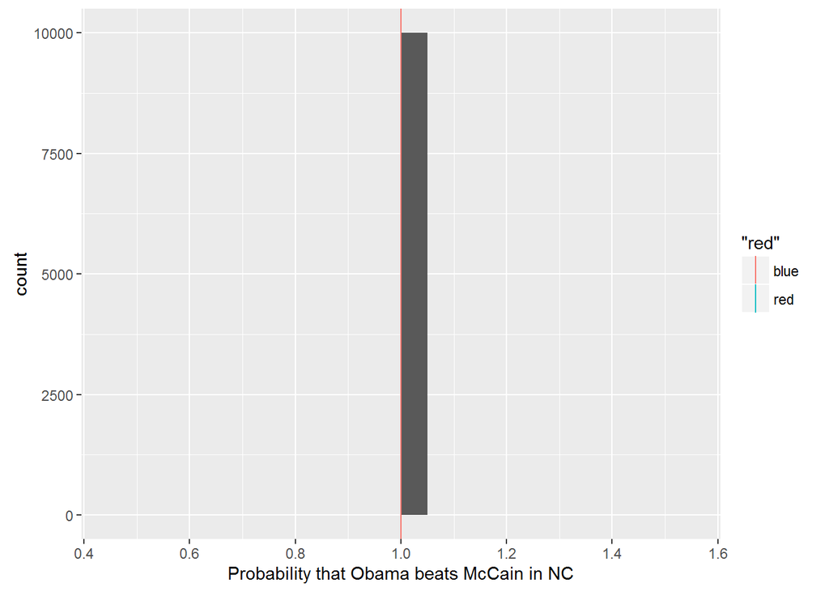

```r
N = 100
B = 1e4
result <- replicate(B, {
    X <- mean(rnorm(N,mu_post,sd_post) > 0)
})
qplot(result, geom = "histogram", bins = 20,
      xlab = "Probability that Obama beats McCain in NC") +
    geom_vline(aes(xintercept = mean(result), color = "red")) +
    geom_vline(aes(xintercept = 1 - pnorm(0, mu_post, sd_post), color = "blue"))
```

So Trump is more likely to win in NC.

3.OH

```r
tabEst<-results%>%
  filter(state=="OH")%>%
  summarize(theta_hat=mean(diff),sigma_hat=sd(diff),tot_poll=n())
tabEst
```

```
## Source: local data frame [1 x 3]
##
##   theta_hat  sigma_hat tot_poll
##       (dbl)      (dbl)    (int)
## 1 0.1633333 0.06403124        9
```

```r
N <- tabEst$tot_poll
B <- (1/tau_prior^2) / (N / tabEst$sigma_hat^2 + 1/tau_prior^2)
sd_post <- sqrt( (1 / tau_prior^2 + N / tabEst$sigma_hat^2)^(-1) )
mu_post <- mu_prior * B + tabEst$theta_hat * (1-B)
```

So in OH, the probability of Trump beating Cruz is

```r
1 - pnorm(0, mu_post, sd_post)
```

```
## [1] 1
```

We can confirm it by Monte Carlo simulation.

[figure not shown]

```r
N = 100
set.seed(12)
qplot(rnorm(N,mu_post,sd_post), geom = "histogram", bins = 20,
      xlab = "difference between Obama and McCain in NC")
```

```r
mean(rnorm(N,mu_post,sd_post)>0)
```

```
## [1] 1
```

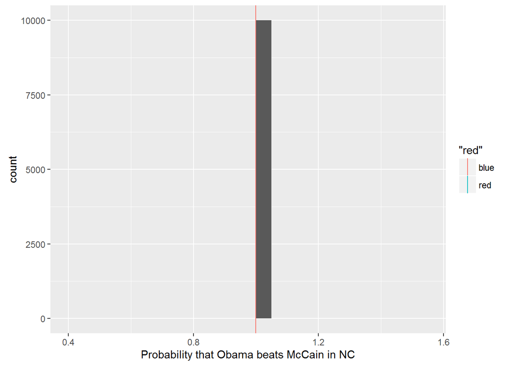

```r
N = 100
B = 1e4
result <- replicate(B, {
    X <- mean(rnorm(N,mu_post,sd_post) > 0)
})
qplot(result, geom = "histogram", bins = 20,
      xlab = "Probability that Obama beats McCain in NC") +
    geom_vline(aes(xintercept = mean(result), color = "red")) +
    geom_vline(aes(xintercept = 1 - pnorm(0, mu_post, sd_post), color = "blue"))
```

So Trump is more likely to win in OH.

4.PA

```r
tabEst<-results%>%
  filter(state=="PA")%>%
  summarize(theta_hat=mean(diff),sigma_hat=sd(diff),tot_poll=n())
tabEst
```

```
## Source: local data frame [1 x 3]
##
##   theta_hat  sigma_hat tot_poll
##       (dbl)      (dbl)    (int)
## 1 0.1766667 0.05278889        6
```

```r
N <- tabEst$tot_poll
B <- (1/tau_prior^2) / (N / tabEst$sigma_hat^2 + 1/tau_prior^2)
sd_post <- sqrt( (1 / tau_prior^2 + N / tabEst$sigma_hat^2)^(-1) )
mu_post <- mu_prior * B + tabEst$theta_hat * (1-B)
```

So in PA, the probability of Trump beating Cruz is

```r
1 - pnorm(0, mu_post, sd_post)
```

```
## [1] 1
```

We can confirm it by Monte Carlo simulation.

[figure not shown]

```r
N = 100
set.seed(1)
qplot(rnorm(N,mu_post,sd_post), geom = "histogram", bins = 20,
      xlab = "difference between Obama and McCain in NC")
```

```r
mean(rnorm(N,mu_post,sd_post)>0)
```

```
## [1] 1
```

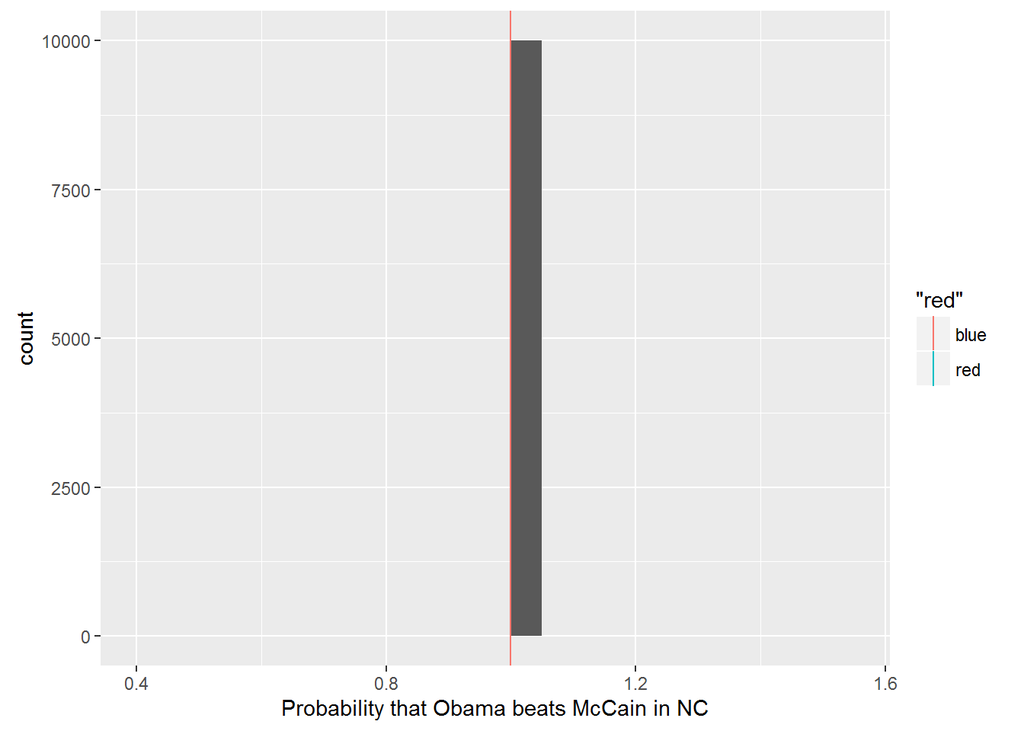

```r
N = 100
B = 1e4
result <- replicate(B, {
    X <- mean(rnorm(N,mu_post,sd_post) > 0)
})
qplot(result, geom = "histogram", bins = 20,
      xlab = "Probability that Obama beats McCain in NC") +
    geom_vline(aes(xintercept = mean(result), color = "red")) +
    geom_vline(aes(xintercept = 1 - pnorm(0, mu_post, sd_post), color = "blue"))
```

5.All(including all 12 states just for idea)

```r
tabEst<-results%>%
  summarize(theta_hat=mean(diff),sigma_hat=sd(diff),tot_poll=n())
tabEst
```

```
## Source: local data frame [1 x 3]
##
##   theta_hat  sigma_hat tot_poll
##       (dbl)      (dbl)    (int)
## 1 0.1708537 0.08340295       82
```

```r
N <- tabEst$tot_poll
B <- (1/tau_prior^2) / (N / tabEst$sigma_hat^2 + 1/tau_prior^2)
sd_post <- sqrt( (1 / tau_prior^2 + N / tabEst$sigma_hat^2)^(-1) )
mu_post <- mu_prior * B + tabEst$theta_hat * (1-B)
```

The probability of Trump beating Cruz is

```r
1 - pnorm(0, mu_post, sd_post)
```

```
## [1] 1
```

We can confirm it by Monte Carlo simulation.

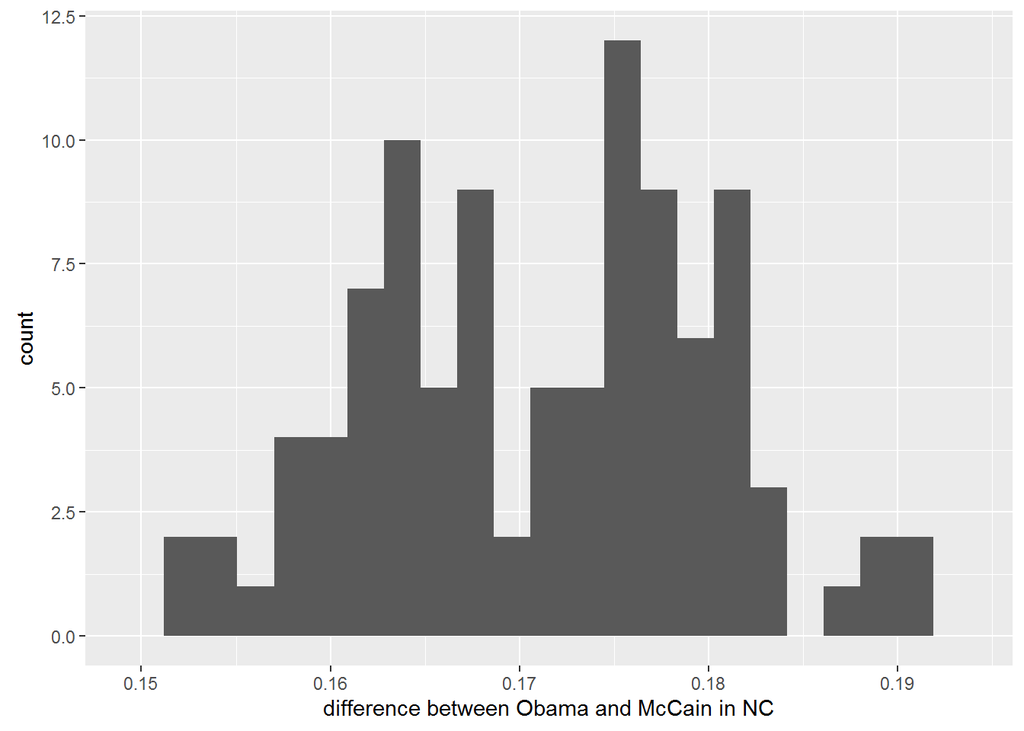

```r
N = 100
set.seed(2)
qplot(rnorm(N,mu_post,sd_post), geom = "histogram", bins = 20,
      xlab = "difference between Obama and McCain in NC")
```

```r
mean(rnorm(N,mu_post,sd_post)>0)
```

```
## [1] 1
```

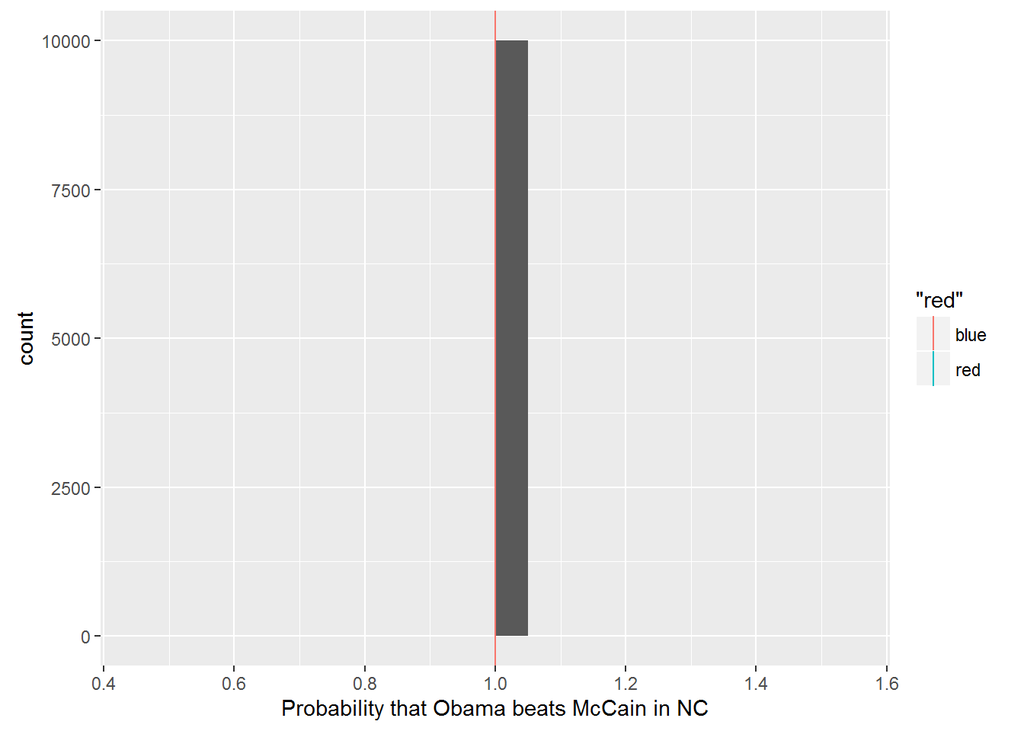

```r
N = 100
B = 1e4
result <- replicate(B, {
    X <- mean(rnorm(N,mu_post,sd_post) > 0)
})
qplot(result, geom = "histogram", bins = 20,
      xlab = "Probability that Obama beats McCain in NC") +
    geom_vline(aes(xintercept = mean(result), color = "red")) +
    geom_vline(aes(xintercept = 1 - pnorm(0, mu_post, sd_post), color = "blue"))
```

Let’s see the delegate assignment again.

```r
delegate
```

```
##    state delegate
## 1     AZ       58
## 2     CA      172
## 3     FL       99
## 4     IL       69
## 5     NC       72
## 6     NJ       51
## 7     NY       95
## 8     OH       66
## 9     PA       71
## 10    UT       40
## 11    WI       42
## 12    WV       34
```

For these four states, the # of delegates are respectively 99, 72, 66, 71, which is quite high.

In conclusion, based on the poll results and election results happened before today, we have reason to believe that Trump has a relatively larger probability to win the republican nomination.